# Bed-1304 Python lab

Seminar 8 - SymPy

28-10-2026

## Last ned seminaroppgavene

Gå inn på canvas eller uit-bed-1304-h25.github.io og finn “Oppgaver”

Last ned “Seminar8_SymPy.ipynb”

Installer Sympy dersom dere ikke har det fra før

```python
%pip install sympy
import sympy as sp
```

## Oppgave 1 Eksempel med 2 Ligninger løst for x

$$f(x) = 300 - x, \quad g(x) = 4x - 10$$

```python
# %pip install sympy dersom det ikke er gjort fra før
import sympy as sp #importerer sympy
x = sp.symbols('x') #Definerer x som et symbol
f = 300 - x #definerer f(x)
g = 4*x - 10 #definerer g(x)
ligninger = sp.solve(f - g, x) #Løser ligningen f(x) - g(x) = 0 for x
print(f"Løsning: {ligninger[0]}") #[0] siden sp.solve returnerer en liste som kan ha flere løsninger
```

```
Løsning: 62
```

## Oppgave 1 LF

$$D(p) = 100 - 2p, \quad S(p) = 3p - 20$$

```python
p = sp.symbols('p')
ettersporsel = 100 - 2*p
tilbud = 3*p - 20

likevekt = sp.solve(ettersporsel - tilbud, p)
print(f"Likevektspris: {likevekt[0]}")
```

```
Likevektspris: 24
```

## Oppgave 2 Eksempel

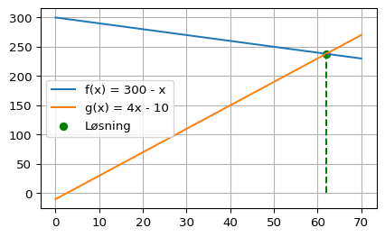

```python
from matplotlib import pyplot as plt
import numpy as np
plt.figure(figsize=(5, 3)) #størrelse så den for plass i presentasjonen
x = np.linspace(0, 70, 100) #100 punkter mellom 0 og 70
plt.plot(x, 300 - x, label='f(x) = 300 - x') #plott f(x)
plt.plot(x, 4*x - 10, label='g(x) = 4x - 10') #plott g(x)

plt.scatter(ligninger[0], 300 - ligninger[0], label='Løsning', color="green") #Setter et punkt der de krysser hverandre
plt.vlines(ligninger[0], 0, 300 - ligninger[0], colors='green', linestyles='dashed') #og en linje opp

plt.legend(loc='center left')#så den ikke dekker løsningen
plt.grid() # Greit for å vise x og y nivåer
plt.show() #"Best practice" for å vise plottet
```

## Oppgave 2 LF kode

```python
import numpy as np
import matplotlib.pyplot as plt

# Definer funksjonene for etterspørsel og tilbud
def D(p):
    return 100 - 2*p

def S(p):
    return 3*p - 20

# Lage et utvalg av priser fra 0 til 50
p_values = np.linspace(0, 50, 500)

# Beregn etterspørsel og tilbud
D_values = D(p_values)
S_values = S(p_values)

# Finn likevektspunktet (fra oppgave 1, der D = S)
# Vi finner at likevekt er p = 24
p_eq = 24
q_eq = D(p_eq)  # eller S(p_eq) - begge gir samme resultat

# Plotte kurvene
plt.plot(p_values, D_values, label="Etterspørsel D(p) = 100 - 2p", color="blue")
plt.plot(p_values, S_values, label="Tilbud S(p) = 3p - 20", color="red")

# Markere likevektspunktet på plottet
plt.scatter(p_eq, q_eq, color="green", zorder=5)
plt.text(p_eq + 1, q_eq + 2, f'Likevekt: p={p_eq}, q={q_eq}', color="green")

# Akser og titler
plt.xlabel('Pris (p)')
plt.ylabel('Mengde (q)')
plt.title('Marked: Etterspørsel og Tilbud')
plt.hlines(q_eq,0, p_eq, color='black',linewidth=1.5, linestyles='dashed')
plt.vlines(p_eq,0,q_eq, color='black',linewidth=1.5, linestyles='dashed')
plt.ylim(0, 120)
plt.xlim(0, 50)
plt.grid(True)
plt.legend()

# Vise grafen
plt.show()
```

## Oppgave 2 LF Figur

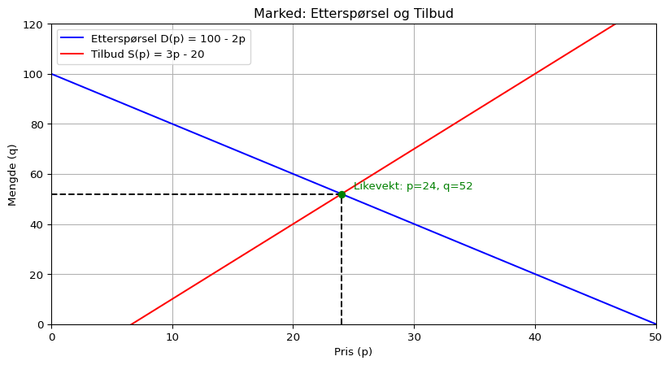

### Oppgave 3a Ekspandere uttrykk. `sp.expand` til å utvide uttrykket $(x+y)^2$ til $x^2 + 2xy + y^2$

```python
x, y, z = sp.symbols('x y z') #Definerer symboler
expr = (x+y)**2 # Skriver uttrykket vårt

new_expr = sp.expand(expr) # Utvider uttrykket
new_expr
```

$\displaystyle x^{2} + 2 x y + y^{2}$

### Oppgave 3b - Faktorisere uttrykket $x^2 + 2xy + y^2$

```python
org_expr = sp.factor(new_expr)
org_expr
```

$\displaystyle \left(x + y\right)^{2}$

Altså når vi vil få vondt så bruker vi sp.expand, når ikke vil det så brukes sp.simplify eller sp.factor for forenkling

## Oppgave 4 Cobb-Douglas

$$f(K, L) = A \cdot K^{\alpha} \cdot L^{\beta}$$
hvor, - $f$ er total produksjon - $K$ er mengden kapital (for eksempel maskiner, utstyr, bygninger) - $L$ er mengden arbeidskraft (antall arbeidere eller arbeidstimer) - $A$ er et mål på produktivitet - $\alpha$ og $\beta$ er eksponenter som viser elastisiteten til henholdsvis kapital og arbeidskraft. De representerer hvor stor andel av produksjonen som kommer fra kapital og arbeidskraft.

Typisk er at $\alpha + \beta = 1$, som som indikerer konstante skalautbytter. Dette betyr at hvis du fordobler både kapital og arbeidskraft, vil produksjonen også fordobles.

### Oppgave 4.1

I økonomi og økonometri er **Cobb-Douglas** sin produksjonsfunksjon ofte brukt, og i denne deloppgaven skal du lage en funksjon som definerer Cobb-Douglas funksjonen, hvor vi setter $A=1$, $\alpha = 0.5$ og $\beta = 0.5$.

```python
A = 1
alpha, beta = 0.5, 0.5
def cobb_douglas(K, L, A, alpha, beta):
    return A * (K ** alpha) * (L ** beta)
```

### Oppgave 4.2 Sympy

Finn den partiell deriverte av Cobb-Douglas funksjonen (mhp $K$), dette kalles *marginale produkt av kapital (MPK)*.

Kommenter resultatet. Ser vi noe spesielt med MPK i forhold til Cobb-Douglas funksjonen?

## Oppgave 4.2 LF

```python
#Definer symboler for kapital (K), arbeidskraft (L), og konstanter A, alpha, beta
A, alpha, beta, K, L = sp.symbols('A alpha beta K L')

#Finn partielle deriverte med hensyn til kapital (K)
dY_dK = sp.diff(cobb_douglas(K, L, A, alpha, beta), K)
dY_dK
```

$\displaystyle \frac{A K^{\alpha} L^{\beta} \alpha}{K}$

kan skrives som $MPK = \alpha \cdot \frac{f(K, L)}{K}$

## Oppgave 4.3 Hvordan utvikler MPK seg, hvis $K$ øker?

Hvis vi holder $L$, $A$, $\alpha$ og $\beta$ konstant. Velg selv en passende måte å presentere dette på. Beskriv hva dette betyr for den totale produksjonen til Cobb-Douglas funksjonen, $f(K, L)$.

Du bestemmer selv verdiene på $L$, $A$, $\alpha$ og $\beta$ (men sørg for $0 < \alpha < 1$, $0 < \beta < 1$ og $\alpha + \beta =1$).

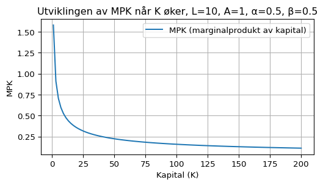

## Oppgave 4.3 figurkode

```python
# Definerer en funksjon for MPK basert på derivert av Cobb-Douglas
def MPK(K, L=10, A=1, alpha=0.5, beta=0.5):
    return (A * alpha * K**(alpha) * L**beta)/K

# Verdier for K
K_values = np.linspace(1, 200, 100)

# Beregn MPK for hver verdi av K
MPK_values = MPK(K_values)

# Plotter MPK som funksjon av K
plt.figure(figsize=(6, 3))
plt.plot(K_values, MPK_values, label='MPK (marginalprodukt av kapital)')
plt.title('Utviklingen av MPK når K øker, L=10, A=1, \u03B1=0.5, \u03B2=0.5')
plt.xlabel('Kapital (K)')
plt.ylabel('MPK')
plt.grid(True)
plt.legend()
plt.show()
```